# Getting Started with R

Yuanting Lu

08/19/2020

### Installation

Please watch the tutorial videos below on how to install *R* and *RStudio*.

- [Installations on Mac OS](https://www.youtube.com/watch?v=Y20P3u3c_1c&list=PLBPoOsxO35OoTX-uTCjDMA79qCkZGwM4j&index=2).
- [Installations on Windows](https://www.youtube.com/watch?v=VLWaED9jTiA&list=PLBPoOsxO35OoTX-uTCjDMA79qCkZGwM4j).

So, *R* is a free software for statistical computing and graphics. But, what is *RStudio* and why is it recommended? Your answers in the end of this semester will probably include some of the reasons given in this article, *Top 6 Reasons You Need to be Using RStudio*.

### *R* Interface

[figure not shown]

[figure not shown]

### RStudio Interface

[figure not shown]

The largest subpanel on the left is the *R* console. Yes, *R* console is embeded in RStudio.

The buttons on the top right corner of each subpanel allow us to minimize, maximize, or resize the particular subpanel. We will learn about the other subpanels as we move along.

### *R* 101

We can either use the *R* console in the *R* interface or in the RStudio interface. For now, the choice does not make any difference. But, when task gets more complicated, the advantage of using RStudio will be clear.

1. Basic calculations. Try the following commands in an *R* console.

```r
3 * 7
15 / 5
9 ^ 2
sqrt(36)
```

**Practice:** Calculate $0.43 + 1.96 \times \sqrt{\frac{0.43(1 - 0.43)}{108}}$.

```r
Close <- c(2.62, 7.94, 33.20, 29.83, 21.85)
```

We deposited the data in the variable `Close`. This was done in two steps.

- The c function combined its arguments (i.e., the prices) and creates a list.
- The arrow sign (`<-`) deposited the content on the right-hand side of the arrow (i.e., the closing prices) to the *R* variable on the left-hand side of the arrow (i.e., the variable `Close`).

Now if we type `Close` in the console, then its content is printed.

```r
Close
```

3. Read data from a file.

Of course, it will not be practical to input larger data set manually. Instead, we read the data set from a file. For example, we can download a one-year trading prices of KODK, from [Yahoo Finance](https://finance.yahoo.com/quote/KODK/history?p=KODK). The default name of the file is `KODK.csv`. It is typically saved in the Downloads folder on our computer. So, after the download, we can type[^1]

- (Mac OS) kodk <- read.csv(“/Users/YourUserName/Downloads/KODK.csv”)
- (Windows) kodk <- read.csv(“C:/Users/YourUserName/Downloads/KODK.csv”)

For the convenience of class activity, a copy of the KODK stock price data in one year (August 19, 2019 – August 19, 2020) is saved online in the course webpage. We can read the data set by using the file URL.

```r
kodk <- read.csv("https://albums.yuanting.lu/sta126/KODK.csv")
```

The line reads the data set from the file `KODK.csv` and saves it in the *R* variable `kodk`, so that from now on, whenever we type `kodk`, *R* knows to pull out this saved data set. Let’s try it.

```r
kodk
```

What is in this data set? All the historical prices of KODK in the recent year. In particular, there is a column named `Close` that has all the closing prices for this stock. Typing the data set name followed by a $ sign and the column name allows us to extract a specific column from the data set.

```r
kodk$Close
```

### *R* Plot 101

Graphs are very effective in delivering information. For example, a plot of the daily KODK stock closing price will clearly reveal a wild ride in the price change.[^2]

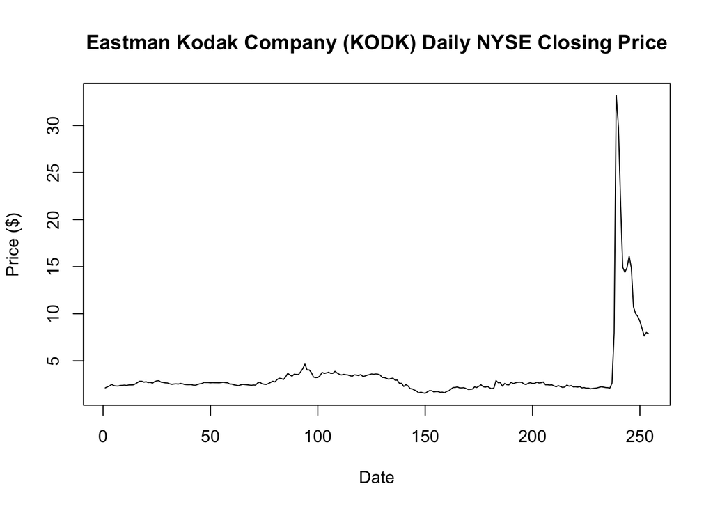

```r
plot(1:254, kodk$Close,
     type = "l",
     main = "Eastman Kodak Company (KODK) Daily NYSE Closing Price",
     xlab = "Date", ylab = "Price ($)")
```

In the plot function[^3],

- 1:254 creates a sequence 1, 2, 3, …, 254, because there are 254 trading days between August 19, 2019 and August 19, 2020. These serve as the x-coordinates.[^4]
- kodk$Close contains the closing prices of the 254 days. There are the y-coordinates.
- The option type = “l”: the letter l stands for line, meaning all the points are connected by line segments. Change it to type = “p” to plot the points only.
- The option main adds a title to the graph.
- The options xlab and ylab add text labels on the x and y-axis, respectively.
[^1]: Alternatively, we can type `kodk <- file.choose()` and select the `KODK.csv` file in the popup dialog window.
[^2]: Bloomberg: [Kodak Shares Add Another 500% as Drug Shift Keeps Boosting Stock](https://www.bloomberg.com/news/articles/2020-07-29/kodak-shares-add-another-500-as-drug-shift-keeps-boosting-stock)
[^3]: In the plot function, type, main, xlab, and ylab are all underlined in the code chunk. They are called options. The plot function works fine without these options. But, we typically add a few options to customize the output of a function.
[^4]: Of course, it makes more sense if we display the calendar dates along the x-axis instead of sequential days. To complish this, replace 1:254 by as.Date(kodk$Date). The data in kodk$Date is in the format YYYY-MM-DD. We know they are dates, but *R* does not. So, the as.Date function tells *R* to treat them as dates.